# Optimal Treatment Analysis

## Outcome Variable

**Outcome Variable:** whz

## Predictor Variables

**Intervention Variable:** nrooms

**Adjustment Set:**

- arm
- sex
- W_mage
- meducyrs
- feducyrs
- hhwealth_quart
- hfoodsec
- W_mhtcm
- W_nchldlt5
- W_parity
- impfloor
- impsan
- safeh20
- delta_W_mage
- delta_meducyrs
- delta_feducyrs
- delta_hhwealth_quart
- delta_hfoodsec
- delta_W_mhtcm
- delta_W_nchldlt5
- delta_W_parity
- delta_impfloor
- delta_impsan
- delta_safeh20

## Stratifying Variables

The analysis was stratified on these variable(s):

- agecat
- studyid
- country

## Data Summary

| agecat | studyid | country | nrooms | n_cell | n |
| --- | --- | --- | --- | --- | --- |
| Birth | ki0047075b-MAL-ED | BANGLADESH | 4+ | 12 | 222 |
| Birth | ki0047075b-MAL-ED | BANGLADESH | 1 | 135 | 222 |
| Birth | ki0047075b-MAL-ED | BANGLADESH | 2 | 47 | 222 |
| Birth | ki0047075b-MAL-ED | BANGLADESH | 3 | 28 | 222 |
| Birth | ki0047075b-MAL-ED | BRAZIL | 4+ | 99 | 167 |
| Birth | ki0047075b-MAL-ED | BRAZIL | 1 | 3 | 167 |
| Birth | ki0047075b-MAL-ED | BRAZIL | 2 | 19 | 167 |
| Birth | ki0047075b-MAL-ED | BRAZIL | 3 | 46 | 167 |
| Birth | ki0047075b-MAL-ED | INDIA | 4+ | 22 | 188 |
| Birth | ki0047075b-MAL-ED | INDIA | 1 | 68 | 188 |
| Birth | ki0047075b-MAL-ED | INDIA | 2 | 66 | 188 |
| Birth | ki0047075b-MAL-ED | INDIA | 3 | 32 | 188 |
| Birth | ki0047075b-MAL-ED | NEPAL | 4+ | 94 | 166 |
| Birth | ki0047075b-MAL-ED | NEPAL | 1 | 34 | 166 |
| Birth | ki0047075b-MAL-ED | NEPAL | 2 | 21 | 166 |
| Birth | ki0047075b-MAL-ED | NEPAL | 3 | 17 | 166 |
| Birth | ki0047075b-MAL-ED | PERU | 4+ | 127 | 252 |
| Birth | ki0047075b-MAL-ED | PERU | 1 | 17 | 252 |
| Birth | ki0047075b-MAL-ED | PERU | 2 | 51 | 252 |
| Birth | ki0047075b-MAL-ED | PERU | 3 | 57 | 252 |
| Birth | ki0047075b-MAL-ED | SOUTH AFRICA | 4+ | 159 | 216 |
| Birth | ki0047075b-MAL-ED | SOUTH AFRICA | 1 | 14 | 216 |
| Birth | ki0047075b-MAL-ED | SOUTH AFRICA | 2 | 20 | 216 |
| Birth | ki0047075b-MAL-ED | SOUTH AFRICA | 3 | 23 | 216 |
| Birth | ki0047075b-MAL-ED | TANZANIA, UNITED REPUBLIC OF | 4+ | 54 | 114 |
| Birth | ki0047075b-MAL-ED | TANZANIA, UNITED REPUBLIC OF | 1 | 6 | 114 |
| Birth | ki0047075b-MAL-ED | TANZANIA, UNITED REPUBLIC OF | 2 | 23 | 114 |
| Birth | ki0047075b-MAL-ED | TANZANIA, UNITED REPUBLIC OF | 3 | 31 | 114 |
| Birth | ki1000108-CMC-V-BCS-2002 | INDIA | 4+ | 5 | 88 |
| Birth | ki1000108-CMC-V-BCS-2002 | INDIA | 1 | 39 | 88 |

[output cut: 154 more lines]

The following strata were considered:

- agecat: 24 months, studyid: ki0047075b-MAL-ED, country: BANGLADESH
- agecat: 24 months, studyid: ki0047075b-MAL-ED, country: BRAZIL
- agecat: 24 months, studyid: ki0047075b-MAL-ED, country: INDIA
- agecat: 24 months, studyid: ki0047075b-MAL-ED, country: NEPAL
- agecat: 24 months, studyid: ki0047075b-MAL-ED, country: PERU
- agecat: 24 months, studyid: ki0047075b-MAL-ED, country: SOUTH AFRICA
- agecat: 24 months, studyid: ki0047075b-MAL-ED, country: TANZANIA, UNITED REPUBLIC OF
- agecat: 24 months, studyid: ki1000108-CMC-V-BCS-2002, country: INDIA
- agecat: 24 months, studyid: ki1000108-IRC, country: INDIA
- agecat: 24 months, studyid: ki1017093b-PROVIDE, country: BANGLADESH
- agecat: 24 months, studyid: ki1017093c-NIH-Crypto, country: BANGLADESH
- agecat: 24 months, studyid: ki1113344-GMS-Nepal, country: NEPAL
- agecat: 24 months, studyid: ki1114097-CONTENT, country: PERU
- agecat: 24 months, studyid: ki1135781-COHORTS, country: INDIA
- agecat: 24 months, studyid: kiGH5241-JiVitA-3, country: BANGLADESH
- agecat: 24 months, studyid: kiGH5241-JiVitA-4, country: BANGLADESH
- agecat: 6 months, studyid: ki0047075b-MAL-ED, country: BANGLADESH
- agecat: 6 months, studyid: ki0047075b-MAL-ED, country: BRAZIL
- agecat: 6 months, studyid: ki0047075b-MAL-ED, country: INDIA
- agecat: 6 months, studyid: ki0047075b-MAL-ED, country: NEPAL
- agecat: 6 months, studyid: ki0047075b-MAL-ED, country: PERU
- agecat: 6 months, studyid: ki0047075b-MAL-ED, country: SOUTH AFRICA
- agecat: 6 months, studyid: ki0047075b-MAL-ED, country: TANZANIA, UNITED REPUBLIC OF
- agecat: 6 months, studyid: ki1000108-CMC-V-BCS-2002, country: INDIA
- agecat: 6 months, studyid: ki1000108-IRC, country: INDIA
- agecat: 6 months, studyid: ki1017093b-PROVIDE, country: BANGLADESH
- agecat: 6 months, studyid: ki1017093c-NIH-Crypto, country: BANGLADESH
- agecat: 6 months, studyid: ki1113344-GMS-Nepal, country: NEPAL
- agecat: 6 months, studyid: ki1114097-CONTENT, country: PERU
- agecat: 6 months, studyid: ki1135781-COHORTS, country: INDIA
- agecat: 6 months, studyid: kiGH5241-JiVitA-3, country: BANGLADESH
- agecat: 6 months, studyid: kiGH5241-JiVitA-4, country: BANGLADESH
- agecat: Birth, studyid: ki0047075b-MAL-ED, country: BANGLADESH
- agecat: Birth, studyid: ki0047075b-MAL-ED, country: BRAZIL
- agecat: Birth, studyid: ki0047075b-MAL-ED, country: INDIA
- agecat: Birth, studyid: ki0047075b-MAL-ED, country: NEPAL
- agecat: Birth, studyid: ki0047075b-MAL-ED, country: PERU
- agecat: Birth, studyid: ki0047075b-MAL-ED, country: SOUTH AFRICA
- agecat: Birth, studyid: ki0047075b-MAL-ED, country: TANZANIA, UNITED REPUBLIC OF
- agecat: Birth, studyid: ki1000108-CMC-V-BCS-2002, country: INDIA
- agecat: Birth, studyid: ki1000108-IRC, country: INDIA
- agecat: Birth, studyid: ki1017093c-NIH-Crypto, country: BANGLADESH
- agecat: Birth, studyid: ki1114097-CONTENT, country: PERU
- agecat: Birth, studyid: ki1135781-COHORTS, country: INDIA
- agecat: Birth, studyid: kiGH5241-JiVitA-3, country: BANGLADESH
- agecat: Birth, studyid: kiGH5241-JiVitA-4, country: BANGLADESH

### Dropped Strata

Some strata were dropped due to rare outcomes:

- agecat: Birth, studyid: ki0047075b-MAL-ED, country: BRAZIL
- agecat: Birth, studyid: ki1017093c-NIH-Crypto, country: BANGLADESH
- agecat: Birth, studyid: ki1114097-CONTENT, country: PERU
- agecat: 6 months, studyid: ki0047075b-MAL-ED, country: BRAZIL
- agecat: 24 months, studyid: ki0047075b-MAL-ED, country: BRAZIL

## Methods Detail

We’re interested in the causal parameters $E[Y_a]$ for all values of $a \in \mathcal{A}$. These parameters represent the mean outcome if, possibly contrary to fact, we intervened to set all units to have $A=a$. Under the randomization and positivity assumptions, these are identified by the statistical parameters $\psi_a=E_W[E_{Y|A,W}(Y|A=a,W)]$. In addition, we’re interested in the mean of $Y$, $E[Y]$ under no intervention (the observed mean). We will estimate these parameters by using SuperLearner to fit the relevant likelihood factors – $E_{Y|A,W}(Y|A=a,W)$ and $p(A=a|W)$, and then updating our likelihood fit using a joint TMLE.

For unadjusted analyses ($W=\{\}$), initial likelihoods were estimated using Lrnr_glm to estimate the simple $E(Y|A)$ and Lrnr_mean to estimate $p(A)$. For adjusted analyses, a small library containing Lrnr_glmnet, Lrnr_xgboost, and Lrnr_mean was used.

Having estimated these parameters, we will then use the delta method to estimate relative risks and attributable risks relative to a prespecified baseline level of $A$.

# Results Detail

## Results Plots

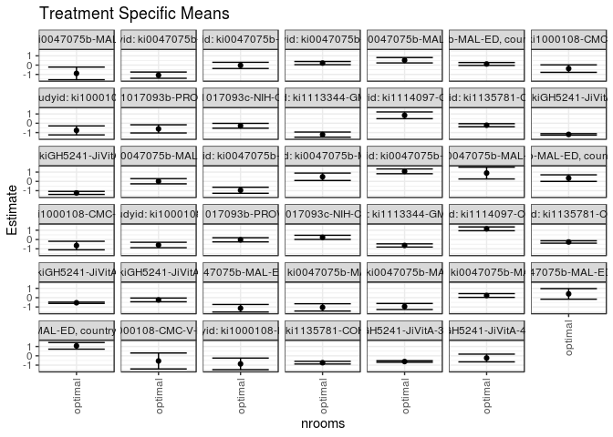

## Results Table

### Parameter: TSM

| agecat | studyid | country | intervention_level | baseline_level | estimate | ci_lower | ci_upper |
| --- | --- | --- | --- | --- | --- | --- | --- |
| Birth | ki0047075b-MAL-ED | BANGLADESH | optimal | observed | -1.1369250 | -1.5426616 | -0.7311885 |
| Birth | ki0047075b-MAL-ED | INDIA | optimal | observed | -1.0441708 | -1.4357324 | -0.6526092 |
| Birth | ki0047075b-MAL-ED | NEPAL | optimal | observed | -0.9499909 | -1.2754620 | -0.6245199 |
| Birth | ki0047075b-MAL-ED | PERU | optimal | observed | 0.2326090 | 0.0314204 | 0.4337977 |
| Birth | ki0047075b-MAL-ED | SOUTH AFRICA | optimal | observed | 0.4054748 | -0.1626075 | 0.9735571 |
| Birth | ki0047075b-MAL-ED | TANZANIA, UNITED REPUBLIC OF | optimal | observed | 1.0700002 | 0.7150000 | 1.4250004 |
| Birth | ki1000108-CMC-V-BCS-2002 | INDIA | optimal | observed | -0.5556529 | -1.4131464 | 0.3018406 |
| Birth | ki1000108-IRC | INDIA | optimal | observed | -0.8687974 | -1.4927596 | -0.2448353 |
| Birth | ki1135781-COHORTS | INDIA | optimal | observed | -0.7405278 | -0.8837654 | -0.5972902 |
| Birth | kiGH5241-JiVitA-3 | BANGLADESH | optimal | observed | -0.6170741 | -0.7004189 | -0.5337293 |
| Birth | kiGH5241-JiVitA-4 | BANGLADESH | optimal | observed | -0.2346991 | -0.6513220 | 0.1819239 |
| 6 months | ki0047075b-MAL-ED | BANGLADESH | optimal | observed | 0.0144462 | -0.2634635 | 0.2923559 |
| 6 months | ki0047075b-MAL-ED | INDIA | optimal | observed | -0.9528755 | -1.2773600 | -0.6283910 |
| 6 months | ki0047075b-MAL-ED | NEPAL | optimal | observed | 0.4945821 | 0.0954492 | 0.8937149 |
| 6 months | ki0047075b-MAL-ED | PERU | optimal | observed | 1.0798241 | 0.8203408 | 1.3393075 |
| 6 months | ki0047075b-MAL-ED | SOUTH AFRICA | optimal | observed | 0.8956565 | 0.2620283 | 1.5292848 |
| 6 months | ki0047075b-MAL-ED | TANZANIA, UNITED REPUBLIC OF | optimal | observed | 0.3499030 | -0.0035923 | 0.7033984 |
| 6 months | ki1000108-CMC-V-BCS-2002 | INDIA | optimal | observed | -0.6483357 | -1.1067127 | -0.1899588 |
| 6 months | ki1000108-IRC | INDIA | optimal | observed | -0.5862169 | -0.8800824 | -0.2923514 |
| 6 months | ki1017093b-PROVIDE | BANGLADESH | optimal | observed | -0.0300715 | -0.2530556 | 0.1929126 |
| 6 months | ki1017093c-NIH-Crypto | BANGLADESH | optimal | observed | 0.2341487 | 0.0108739 | 0.4574234 |
| 6 months | ki1113344-GMS-Nepal | NEPAL | optimal | observed | -0.6348643 | -0.8075604 | -0.4621682 |
| 6 months | ki1114097-CONTENT | PERU | optimal | observed | 1.1501729 | 0.9472435 | 1.3531024 |
| 6 months | ki1135781-COHORTS | INDIA | optimal | observed | -0.2640952 | -0.3928341 | -0.1353563 |
| 6 months | kiGH5241-JiVitA-3 | BANGLADESH | optimal | observed | -0.5460281 | -0.6134223 | -0.4786339 |
| 6 months | kiGH5241-JiVitA-4 | BANGLADESH | optimal | observed | -0.2421609 | -0.4412902 | -0.0430317 |
| 24 months | ki0047075b-MAL-ED | BANGLADESH | optimal | observed | -0.8909824 | -1.5721406 | -0.2098241 |
| 24 months | ki0047075b-MAL-ED | INDIA | optimal | observed | -1.0803915 | -1.4144239 | -0.7463591 |
| 24 months | ki0047075b-MAL-ED | NEPAL | optimal | observed | -0.0316368 | -0.3637527 | 0.3004791 |
| 24 months | ki0047075b-MAL-ED | PERU | optimal | observed | 0.2184541 | 0.0484524 | 0.3884559 |
| 24 months | ki0047075b-MAL-ED | SOUTH AFRICA | optimal | observed | 0.5243472 | 0.2347656 | 0.8139288 |
| 24 months | ki0047075b-MAL-ED | TANZANIA, UNITED REPUBLIC OF | optimal | observed | 0.1228414 | -0.0332145 | 0.2788973 |
| 24 months | ki1000108-CMC-V-BCS-2002 | INDIA | optimal | observed | -0.3752332 | -0.7777017 | 0.0272354 |
| 24 months | ki1000108-IRC | INDIA | optimal | observed | -0.7691423 | -1.2512427 | -0.2870419 |
| 24 months | ki1017093b-PROVIDE | BANGLADESH | optimal | observed | -0.6041460 | -1.0418922 | -0.1663998 |
| 24 months | ki1017093c-NIH-Crypto | BANGLADESH | optimal | observed | -0.2707049 | -0.5302025 | -0.0112072 |
| 24 months | ki1113344-GMS-Nepal | NEPAL | optimal | observed | -1.2202929 | -1.4958126 | -0.9447732 |
| 24 months | ki1114097-CONTENT | PERU | optimal | observed | 0.8527670 | 0.4912163 | 1.2143177 |
| 24 months | ki1135781-COHORTS | INDIA | optimal | observed | -0.2118597 | -0.3750137 | -0.0487056 |
| 24 months | kiGH5241-JiVitA-3 | BANGLADESH | optimal | observed | -1.1997890 | -1.2775687 | -1.1220093 |
| 24 months | kiGH5241-JiVitA-4 | BANGLADESH | optimal | observed | -1.2407620 | -1.4032445 | -1.0782796 |

### Parameter: E(Y)

| agecat | studyid | country | intervention_level | baseline_level | estimate | ci_lower | ci_upper |
| --- | --- | --- | --- | --- | --- | --- | --- |
| Birth | ki0047075b-MAL-ED | BANGLADESH | observed | observed | -0.9902252 | -1.1311070 | -0.8493435 |
| Birth | ki0047075b-MAL-ED | INDIA | observed | observed | -1.0536702 | -1.1965043 | -0.9108361 |
| Birth | ki0047075b-MAL-ED | NEPAL | observed | observed | -0.9174699 | -1.0573845 | -0.7775553 |
| Birth | ki0047075b-MAL-ED | PERU | observed | observed | -0.0384921 | -0.1542085 | 0.0772244 |
| Birth | ki0047075b-MAL-ED | SOUTH AFRICA | observed | observed | -0.0073148 | -0.1632037 | 0.1485740 |
| Birth | ki0047075b-MAL-ED | TANZANIA, UNITED REPUBLIC OF | observed | observed | 0.8024561 | 0.5990025 | 1.0059098 |
| Birth | ki1000108-CMC-V-BCS-2002 | INDIA | observed | observed | -0.6275000 | -0.9746292 | -0.2803708 |
| Birth | ki1000108-IRC | INDIA | observed | observed | -1.0053372 | -1.1922119 | -0.8184626 |
| Birth | ki1135781-COHORTS | INDIA | observed | observed | -0.9778087 | -1.0126530 | -0.9429644 |
| Birth | kiGH5241-JiVitA-3 | BANGLADESH | observed | observed | -0.7238563 | -0.7437124 | -0.7040002 |
| Birth | kiGH5241-JiVitA-4 | BANGLADESH | observed | observed | -0.3683163 | -0.4490504 | -0.2875821 |
| 6 months | ki0047075b-MAL-ED | BANGLADESH | observed | observed | -0.1354618 | -0.2647919 | -0.0061317 |
| 6 months | ki0047075b-MAL-ED | INDIA | observed | observed | -0.7056667 | -0.8312524 | -0.5800810 |
| 6 months | ki0047075b-MAL-ED | NEPAL | observed | observed | 0.1110452 | -0.0202712 | 0.2423616 |
| 6 months | ki0047075b-MAL-ED | PERU | observed | observed | 1.0527407 | 0.9299728 | 1.1755087 |
| 6 months | ki0047075b-MAL-ED | SOUTH AFRICA | observed | observed | 0.5403280 | 0.3866002 | 0.6940558 |
| 6 months | ki0047075b-MAL-ED | TANZANIA, UNITED REPUBLIC OF | observed | observed | 0.5170513 | 0.3872178 | 0.6468847 |
| 6 months | ki1000108-CMC-V-BCS-2002 | INDIA | observed | observed | -0.5026766 | -0.6536848 | -0.3516685 |
| 6 months | ki1000108-IRC | INDIA | observed | observed | -0.5900821 | -0.7252457 | -0.4549185 |
| 6 months | ki1017093b-PROVIDE | BANGLADESH | observed | observed | -0.2083706 | -0.2927992 | -0.1239419 |
| 6 months | ki1017093c-NIH-Crypto | BANGLADESH | observed | observed | 0.0297622 | -0.0491685 | 0.1086930 |
| 6 months | ki1113344-GMS-Nepal | NEPAL | observed | observed | -0.6047987 | -0.6909649 | -0.5186325 |
| 6 months | ki1114097-CONTENT | PERU | observed | observed | 1.0684318 | 0.9515274 | 1.1853362 |
| 6 months | ki1135781-COHORTS | INDIA | observed | observed | -0.7088012 | -0.7411274 | -0.6764750 |
| 6 months | kiGH5241-JiVitA-3 | BANGLADESH | observed | observed | -0.5930302 | -0.6125738 | -0.5734865 |
| 6 months | kiGH5241-JiVitA-4 | BANGLADESH | observed | observed | -0.3901595 | -0.4274150 | -0.3529041 |
| 24 months | ki0047075b-MAL-ED | BANGLADESH | observed | observed | -0.8208255 | -0.9429246 | -0.6987264 |
| 24 months | ki0047075b-MAL-ED | INDIA | observed | observed | -0.9522907 | -1.0676596 | -0.8369219 |
| 24 months | ki0047075b-MAL-ED | NEPAL | observed | observed | -0.3764474 | -0.4898516 | -0.2630431 |
| 24 months | ki0047075b-MAL-ED | PERU | observed | observed | 0.1199005 | -0.0000331 | 0.2398341 |
| 24 months | ki0047075b-MAL-ED | SOUTH AFRICA | observed | observed | 0.4267017 | 0.3074751 | 0.5459283 |
| 24 months | ki0047075b-MAL-ED | TANZANIA, UNITED REPUBLIC OF | observed | observed | 0.0500935 | -0.0748234 | 0.1750103 |
| 24 months | ki1000108-CMC-V-BCS-2002 | INDIA | observed | observed | -0.5571505 | -0.6585247 | -0.4557763 |
| 24 months | ki1000108-IRC | INDIA | observed | observed | -0.7416790 | -0.8323562 | -0.6510017 |
| 24 months | ki1017093b-PROVIDE | BANGLADESH | observed | observed | -0.8879412 | -0.9708680 | -0.8050144 |
| 24 months | ki1017093c-NIH-Crypto | BANGLADESH | observed | observed | -0.6103502 | -0.7050157 | -0.5156847 |
| 24 months | ki1113344-GMS-Nepal | NEPAL | observed | observed | -1.1315863 | -1.2192240 | -1.0439487 |
| 24 months | ki1114097-CONTENT | PERU | observed | observed | 0.5668293 | 0.4302437 | 0.7034148 |
| 24 months | ki1135781-COHORTS | INDIA | observed | observed | -0.6612799 | -0.6944511 | -0.6281088 |
| 24 months | kiGH5241-JiVitA-3 | BANGLADESH | observed | observed | -1.2967966 | -1.3200807 | -1.2735126 |
| 24 months | kiGH5241-JiVitA-4 | BANGLADESH | observed | observed | -1.2231776 | -1.2550332 | -1.1913220 |

### Parameter: PAR

| agecat | studyid | country | intervention_level | baseline_level | estimate | ci_lower | ci_upper |
| --- | --- | --- | --- | --- | --- | --- | --- |
| Birth | ki0047075b-MAL-ED | BANGLADESH | optimal | observed | 0.1466998 | -0.2615076 | 0.5549073 |
| Birth | ki0047075b-MAL-ED | INDIA | optimal | observed | -0.0094994 | -0.3780837 | 0.3590849 |
| Birth | ki0047075b-MAL-ED | NEPAL | optimal | observed | 0.0325210 | -0.2805472 | 0.3455893 |
| Birth | ki0047075b-MAL-ED | PERU | optimal | observed | -0.2711011 | -0.4596500 | -0.0825522 |
| Birth | ki0047075b-MAL-ED | SOUTH AFRICA | optimal | observed | -0.4127896 | -0.9567903 | 0.1312110 |
| Birth | ki0047075b-MAL-ED | TANZANIA, UNITED REPUBLIC OF | optimal | observed | -0.2675440 | -0.6162983 | 0.0812103 |
| Birth | ki1000108-CMC-V-BCS-2002 | INDIA | optimal | observed | -0.0718471 | -0.9067426 | 0.7630484 |
| Birth | ki1000108-IRC | INDIA | optimal | observed | -0.1365398 | -0.7471912 | 0.4741115 |
| Birth | ki1135781-COHORTS | INDIA | optimal | observed | -0.2372809 | -0.3804897 | -0.0940720 |
| Birth | kiGH5241-JiVitA-3 | BANGLADESH | optimal | observed | -0.1067822 | -0.1893928 | -0.0241716 |
| Birth | kiGH5241-JiVitA-4 | BANGLADESH | optimal | observed | -0.1336172 | -0.5474706 | 0.2802362 |
| 6 months | ki0047075b-MAL-ED | BANGLADESH | optimal | observed | -0.1499080 | -0.4007601 | 0.1009440 |
| 6 months | ki0047075b-MAL-ED | INDIA | optimal | observed | 0.2472088 | -0.0537765 | 0.5481942 |
| 6 months | ki0047075b-MAL-ED | NEPAL | optimal | observed | -0.3835369 | -0.7512639 | -0.0158098 |
| 6 months | ki0047075b-MAL-ED | PERU | optimal | observed | -0.0270834 | -0.2636858 | 0.2095190 |
| 6 months | ki0047075b-MAL-ED | SOUTH AFRICA | optimal | observed | -0.3553286 | -0.9623854 | 0.2517283 |
| 6 months | ki0047075b-MAL-ED | TANZANIA, UNITED REPUBLIC OF | optimal | observed | 0.1671483 | -0.1667552 | 0.5010517 |
| 6 months | ki1000108-CMC-V-BCS-2002 | INDIA | optimal | observed | 0.1456591 | -0.2882885 | 0.5796067 |
| 6 months | ki1000108-IRC | INDIA | optimal | observed | -0.0038652 | -0.2837825 | 0.2760521 |
| 6 months | ki1017093b-PROVIDE | BANGLADESH | optimal | observed | -0.1782990 | -0.3854705 | 0.0288724 |
| 6 months | ki1017093c-NIH-Crypto | BANGLADESH | optimal | observed | -0.2043864 | -0.4126949 | 0.0039220 |
| 6 months | ki1113344-GMS-Nepal | NEPAL | optimal | observed | 0.0300656 | -0.1187146 | 0.1788457 |
| 6 months | ki1114097-CONTENT | PERU | optimal | observed | -0.0817411 | -0.2434069 | 0.0799246 |
| 6 months | ki1135781-COHORTS | INDIA | optimal | observed | -0.4447060 | -0.5739189 | -0.3154931 |
| 6 months | kiGH5241-JiVitA-3 | BANGLADESH | optimal | observed | -0.0470021 | -0.1125805 | 0.0185764 |
| 6 months | kiGH5241-JiVitA-4 | BANGLADESH | optimal | observed | -0.1479986 | -0.3374805 | 0.0414833 |
| 24 months | ki0047075b-MAL-ED | BANGLADESH | optimal | observed | 0.0701569 | -0.5832385 | 0.7235523 |
| 24 months | ki0047075b-MAL-ED | INDIA | optimal | observed | 0.1281008 | -0.1701510 | 0.4263525 |
| 24 months | ki0047075b-MAL-ED | NEPAL | optimal | observed | -0.3448106 | -0.6534631 | -0.0361581 |
| 24 months | ki0047075b-MAL-ED | PERU | optimal | observed | -0.0985536 | -0.2205909 | 0.0234836 |
| 24 months | ki0047075b-MAL-ED | SOUTH AFRICA | optimal | observed | -0.0976455 | -0.3882412 | 0.1929502 |
| 24 months | ki0047075b-MAL-ED | TANZANIA, UNITED REPUBLIC OF | optimal | observed | -0.0727479 | -0.2065194 | 0.0610236 |
| 24 months | ki1000108-CMC-V-BCS-2002 | INDIA | optimal | observed | -0.1819174 | -0.5698313 | 0.2059966 |
| 24 months | ki1000108-IRC | INDIA | optimal | observed | 0.0274633 | -0.4423644 | 0.4972911 |
| 24 months | ki1017093b-PROVIDE | BANGLADESH | optimal | observed | -0.2837952 | -0.7123530 | 0.1447627 |
| 24 months | ki1017093c-NIH-Crypto | BANGLADESH | optimal | observed | -0.3396453 | -0.5784144 | -0.1008763 |
| 24 months | ki1113344-GMS-Nepal | NEPAL | optimal | observed | 0.0887065 | -0.1734311 | 0.3508442 |
| 24 months | ki1114097-CONTENT | PERU | optimal | observed | -0.2859377 | -0.5958220 | 0.0239466 |
| 24 months | ki1135781-COHORTS | INDIA | optimal | observed | -0.4494202 | -0.6111379 | -0.2877025 |
| 24 months | kiGH5241-JiVitA-3 | BANGLADESH | optimal | observed | -0.0970077 | -0.1722584 | -0.0217570 |
| 24 months | kiGH5241-JiVitA-4 | BANGLADESH | optimal | observed | 0.0175844 | -0.1355250 | 0.1706938 |